# Group Assignment (part 1) - Heat Smart Orkney Report

## Contents :

- Introduction: Understanding the Orkney Isles Energy Curtailment Challenge
- The Project: Setting the Context
- Project Objective
- Approach and Methodology
- Dataset Description
- Exploratory Data Analysis: Supply Side
- Question 1: How much energy is currently curtailed annually across the Orkney Isles?
- Exploratory Data Analysis: Demand Side
- Question 2 and 3: How much can this be reduced by different levels of DR penetration?
- Cost Benefit Analysis
- Cost Component Estimates
- Project Valuation - Cash Flow and Net Present Value Analysis
- Discussion of Financial Analysis Results
- Consumer Benefits
- Environmental Impact
- Conclusions on Business Analysis and Actionable Business Recommendations
- Further Considerations and Recommendations
- References

```python
import numpy as np
import matplotlib.pyplot as plt
import pandas as pd
from datetime import datetime, timedelta, date
from scipy.optimize import curve_fit
import numpy_financial as npf

import warnings
warnings.filterwarnings('ignore')
```

## Introduction: Understanding the Orkney Isles Energy Curtailment Challenge

The Orkney Isles is an archipelago located off the North Coast of Great Britain, which is part of the Northern Isles of Scotland. Due to their unique geographical position, the Orkney Islands have a fantastic potential for renewable energy production, benefiting from some of the most optimal conditions for wind and hydro energy generation, due to strong winds all year long as well as strong waves and tides.

Developments in the renewable energy sector meant that Orkney continued to expand its renewable energy production over the last decade, becoming a net exporter of electricity in 2013 and producing 103% of the electricity load for the isles from renewable energy. Energy generation in Orkney continued to increase even further over the last period, reaching 128% of local demand in 2020 (OREF, 2023).

While Orkney has a leading presence on the renewable energy stage due to the innovative and clean energy solutions, this does not come without challenges. Given the unpredictability and uncertainty of renewable energy production and the limitations imposed by the electricity network connection between Orkney and mainland Britain.

Specifically, Orkney is connected to the mainland through a 40 MW cable connection, which limits the amount of surplus energy supply that can be distributed into the wider electricity network during periods when local production exceeds local demand. This results in frequent and significant energy curtailments on the islands, required to balance the energy system.

The absence of an effective and feasible strategy to manage the demand response during times of high production potential complemented by inability to distribute this energy into the wider electric network results in lost revenue opportunities for owners of wind turbines in Orkney (both domestic and business). From a broader environmental perspective, this also leads to wastage of renewable energy, in favour of non-green energy alternatives based on fossil fuels to meet demand in other parts of Britain. As such, the great renewable energy potential of Orkney Isles, which as of end of 2015 had over 650 available wind generators out of which approximately 570 were domestic wind turbines (and app. 80 non-domestic) (OREF, 2016), is far from being fully exploited.

## The Project: Setting the Context

In light of the energy curtailment challenge faced by Orkney Isles, Kaluza consulting in partnership with Community Energy Scotland, is running a trial programme called Heat Smart Orkney (HSO), aimed at assessing the feasibility and potential value of Kaluza’s proposed solution, which entails smart, technologically driven energy demand response (DR) management. Demand response programmes, which involve shifting the energy usage and smoothing energy consumption around peak periods by altering consumer demand patterns through the right incentive mechanisms such as price discounts, are generally used when there is less flexibility on the supply side (due to inability to control external natural factors such as wind) or considering the incumbent situation where as long as fossil fuel energy is still produced, curtailing the production of green energy is suboptimal and although the ideal solution would be to produce renewable energy at the maximum capacity.

In the case of Orkney Isles, the potential solution proposed by Kaluza involves the use of Internet of Things (IoT) technologies and installation of smart devices in households that would enable the automatic switch on of household devices during periods of high energy production. Specifically, the solution proposed by Kaluza would be to switch on local devices during periods of high supply in order to consume some of the energy that otherwise would be curtailed and offer discounted energy rates during these intervals of time of high energy production.

This would mean that generators would be getting some additional revenue during periods of high energy production, as opposed to none in the energy curtailment scenario; this would also be beneficial for the consumers in Orkney Isles as they would optimise their electric energy consumption at the best possible price by consuming more when energy is cheaper and reducing their consumption during periods when energy is more expensive, resulting in overall cost savings.

However, understanding the viability and potential benefits of such a project requires an in-depth analysis of various Demand-Response scenarios compared to the baseline scenario, estimates of revenue lost due to curtailment, understanding of the current consumption patterns in Orkney Isles, particularly the consumption component that is flexible in terms of timing and which could be altered to achieve optimal outcomes for all involved stakeholders.

## Project Objective

In order to evaluate this business proposition we aim to answer the following 3 questions:

**Question 1**: How much energy is currently curtailed annually across the Orkney Isles?  
**Question 2**: How much can this be reduced by different levels of DR penetration?  
**Question 3**: How many local households would need to be on our DR scheme in order to supply this level of DR?

The overarching goal of the project proposed by Kaluza is to control the heating of storage heaters and hot water cylinders using a market-driven approach to mitigate curtailment. By enabling these heating devices to consume the excess renewable energy from the local wind generators that would otherwise be curtailed, the business proposition aims to devise an efficient DR management system.

In light of the above, our assessment aims to provide an estimate for the value of this project proposal, assess its financial viability and define the set of circumstances and assumptions that would make the project profitable.

## Approach and Methodology

In order to answer the three key questions asked by Kaluza, we followed the below approach:

**1) Exploratory data analysis of datasets provided** - Once data is cleaned to remove missing or potentially problematic data points, an in-depth analysis of the two data sets on turbine data and residential demand data is conducted to gain insights into turbine capacity for the Rousey turbine and the relationship between energy capacity, wind speed, the minimum wind speed required to produce electricity and how excess capacity translates into energy curtailment. On the demand side, we analyse demand patterns across the full time period to understand seasonality and consumption patterns, turning then to analysing consumption within smaller time intervals such as daily and hourly.

**2) Assumptions setting, identification and sourcing of additional data points**- Once we gained an in-depth understanding of the data we proceed to setting the necessary assumptions in order to develop a model for estimating an overall energy curtailment figure for Orkney Isles for a set time frame. Research was conducted to find additional information about the overall number of turbines in Orkney, how the curtailment mechanism is deployed, how the estimates of energy curtailed for the Rousey turbine could be extrapolated to generate a reliable estimate for the overall yearly curtailment and the technical aspects of how the IoT devices function. For these purposes we have conducted research and analysis of multiple relevant data sources and industry reports such as Energy Audit Reports for Orkey Isles, information from the Orkney Renewable Energy Forum and the Heat Smart Orkney (HSO) Project. Key data and assumptions made in these reports were used for assumptions setting in our analysis.

**3) Estimating energy curtailment for a given year for Orkney Isles** - We approach this problem from two angles: curtailment for a single turbine and for turbines throughout Orkney. For single turbine curtailment, we have the wind speed, set point and power generation data for a 900kW turbine (in Rousay). We determine the maximum power generated under different wind speeds, by the turbine when uncurtailed. Then, for each time point, we calculate the curtailment amount as the difference between that maximum level and actual level. Next, for the estimation of curtailment throughout the isles, we compare the supply side (maximum potential power generation given the current wind speed, scaled up by a factor from our single turbine) and the demand side (local load plus exported power). Any power surplus (excess supply) is treated as curtailment.

**4) Sensitivity analysis at different DR % penetration rates** - once an estimate for the yearly energy curtailment figures was obtained, we proceeded to conduct a sensitivity analysis of the curtailment reduction potential at various % levels of demand response penetration. Three levels of DR % penetration were considered initially to capture worst, moderate and best case scenarios. This analysis was further expanded assessing the impacts at smaller increments of DR % penetration in the context of financial analysis.

**5) Financial Analysis using NPV valuation techniques** - in this section we turn to the viability and valuation assessment of the project, analysing how the potential curtailment reduction estimated in the first part would translate into monetary terms. An in-depth study of cost components for a similar project was conducted to identify all relevant cost components for this project (turbine, device and rebate related) both in the set up year and on an ongoing basis. Similarly, we proposed a model for the estimation of yearly revenue streams that could be achieved at different penetration levels, identifying and accounting for other practical limitations not captured in the initial model. Finally, NPV valuation techniques are used to determine the NPV value of the project at various DR levels and also to identify the minimum level of DR penetration at which the project would be viable from an NPV perspective (that is, the project would have a positive NPV). In this section we also conducted a qualitative assessment of the impact of the project on other relevant stakeholders such as consumers and most importantly, we discuss environmental considerations.

**6) Discussion of practical business implications** - results are analysed from a business perspective and translated into actionable points for Kaluza and the HSO project to be accounted for when designing the business approach and when deciding whether to proceed with the project, and if so, under what circumstances.

**7) Discussion of further recommendations** - in the final section we have taken the discussion a step further by presenting a set of recomendations that go above and beyond the current project proposition. In light of our findings, we deem that in addition to this project, other options should be considered by Kaluza in order to enhance the energy curtailment reductions even further.

## Dataset Description

The provided datasets include telemetry data from a wind turbine on Rousay Island in the Orkney Isles and aggregated residential electricity demand data.

**Turbine Telemetry Data (Turbine_telemetry.csv):**

- **Timestamp**: This column represents the date and time (in UTC) when the measurement was taken. The timestamp indicates the end of the measurement period.
- **Power_kw**: This column shows the average power output in kilowatts (kW) during the measurement period for the wind turbine.
- **Setpoint_kw:** The setpoint refers to the mean maximum-allowed generator output during the measurement period. It indicates whether the turbine is being forcibly curtailed by the network operator. If the setpoint is equal to the generator's maximum output (e.g., 900 kW), it implies that the generator is operating without any curtailment.
- **Wind_ms**: This column displays the mean wind speed in meters per second (m/s) at the location of the turbine during the measurement period.

**Residential Demand Data (Residential_demand.csv):**

- **Timestamp:** Similar to the turbine telemetry data, this column represents the date and time (in UTC) of the measurement, with the timestamp indicating the end of the measurement period.
- **Demand_mean_kw:** This column shows the average electricity demand in kilowatts (kW) from a sample of households during the measurement period. It provides an aggregated value of the electricity consumed by the included households.
- **N_households:** This column represents the number of households included in the aggregated statistics for the given measurement period.

These datasets provide information on the power output and setpoint of a wind turbine, as well as the average electricity demand from a sample of households over a specific period. They can be used to analyze the relationship between wind speed and turbine power output, investigate curtailment patterns, and explore the electricity demand patterns of residential consumers in the area.

## Exploratory Data Analysis: Supply Side

```python
# Reading Wind Turbine Telemetry Data
wind = pd.read_csv('Turbine_telemetry.csv')
```

```python
# Renaming columns for clarity and easier data manipulation
wind.columns = ['time', 'gen_power', 'setpt', 'speed']
```

```python
# Converting the 'time' column to datetime format for better time-based analysis
wind
wind['time'] = pd.to_datetime(wind['time'], errors='coerce')
```

```python
# Counting the number of values in the 'setpt' column that are less than 900 and displaying the result
len(wind['setpt'][wind['setpt']<900])
```

```
121254
```

Wind speed plays a crucial role in determining the energy output of a wind turbine. When the wind speed is higher, the turbine's blades rotate faster within their design limits, resulting in increased mechanical power and ultimately more electrical power generated by the generator. Additionally, the power output of the turbine generally follows a cubic relationship with the wind speed. This means that as the wind speed increases, the power output of the turbine grows significantly. After a certain point, the power output plateaus even as wind speeds increase; this is a safety feature. The relationship between wind speed (measured in meters per second) and power output (measured in kilowatts) can be observed in the accompanying figure.

The 'alpha' parameter sets the transparency of the markers, allowing for better visualization of densely populated data points.

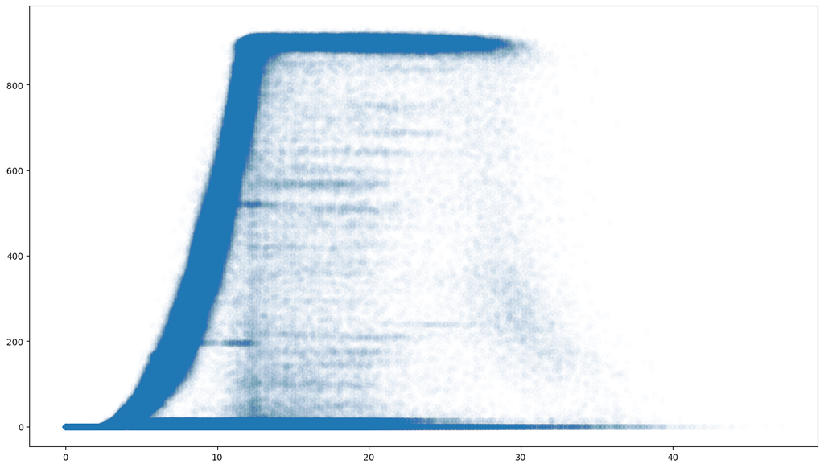

```python
plt.figure(figsize=(16,9))
plt.scatter(wind.speed, wind.gen_power, alpha=0.01) # alpha here is important
```

### Finding the minimum wind speed required to produce power

Filtering the 'speed' column to select wind speed values where the power output is greater than or equal to 10 kW. The quantile(0.1) function calculates the 10th percentile of the selected wind speed values, providing the minimum wind speed necessary to produce power.

```python
v_min = wind['speed'][(wind['gen_power'] >= 10)].quantile(0.1) # 10% quantile
v_min
```

```
5.0
```

### Data Cleaning

We start by filtering the dataset based on the setpoint ('setpt') column to include only instances when the wind turbine was not constrained (setpoint = 900). This step ensures that only data points where the turbine was operating without curtailment are considered for further analysis.

Removal of Data Points with No Power Output: Next, the code identifies data points where the wind speed is sufficient for power production (above a minimum threshold which we previously computed) but the power output is extremely low (close to zero). These data points may indicate instances when the turbine was manually switched off. By assigning NaN (missing value) to these rows, they can be easily identified and excluded from subsequent analysis.

Handling Missing Values: We then proceed to drop rows with missing values (NaN) from the DataFrame, ensuring that only complete data points are retained. This step helps in maintaining the integrity of the dataset for further analysis and modeling.

By following this approach, we aim to focus on the relevant data points where the wind turbine was not constrained and remove instances with no power output even at sufficient wind speeds.

```python
# we only want to use data when the turbine was not constrained
df = wind[wind.setpt == 900]

# remove data points when the wind speed is fast enough for power production but there is no power; turbine is probably manually switched off here
df.loc[((df.speed >= v_min) & (df.gen_power.abs() <= 1e-5))] = np.nan

# remove all missing values from the dataframe
df = df.dropna(0, inplace=False)

df
```

|  | time | gen_power | setpt | speed |
| --- | --- | --- | --- | --- |
| 0 | 2015-05-28 00:00:23 | 80.0 | 900.0 | 4.9 |
| 1 | 2015-05-28 00:01:23 | 78.0 | 900.0 | 5.4 |
| 2 | 2015-05-28 00:02:23 | 52.0 | 900.0 | 4.9 |
| 3 | 2015-05-28 00:03:23 | 57.0 | 900.0 | 4.6 |
| 4 | 2015-05-28 00:04:23 | 54.0 | 900.0 | 4.6 |
| ... | ... | ... | ... | ... |
| 1069631 | 2018-01-11 06:10:32 | 99.0 | 900.0 | 5.9 |
| 1069632 | 2018-01-11 06:11:32 | 105.0 | 900.0 | 5.7 |
| 1069633 | 2018-01-11 06:12:32 | 93.0 | 900.0 | 5.8 |
| 1069634 | 2018-01-11 06:13:32 | 97.0 | 900.0 | 5.5 |
| 1069635 | 2018-01-11 06:14:32 | 92.0 | 900.0 | 5.5 |

931575 rows × 4 columns

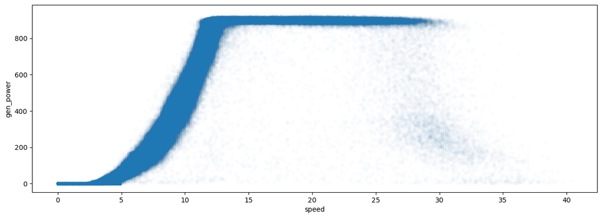

```python
# Producing the scatter plot again
df.plot.scatter('speed', 'gen_power', alpha=0.01, figsize=(15, 5)) # a lot cleaner!
```

The plotted graph illustrates the connection between wind speed and power output. It is evident that there is a maximum power limit set at 900 KW. Furthermore, a positive and accelerating correlation between wind speed and power output is clearly observable. This indicates that as the wind speed increases, the power output of the wind turbine grows at an increasingly faster rate.

```python
# Defining wind speed intervals (bins)
bins = np.arange(0, 60, .2)

# Grouping data by wind speed intervals
cuts = pd.cut(df.speed, bins) # <-- generating bins for the windspeep
print(cuts) # <-- remove comment to see the output
gp = df.gen_power.groupby(cuts) # iterator
```

```
0          (4.8, 5.0]
1          (5.2, 5.4]
2          (4.8, 5.0]
3          (4.4, 4.6]
4          (4.4, 4.6]
              ...
1069631    (5.8, 6.0]
1069632    (5.6, 5.8]
1069633    (5.6, 5.8]
1069634    (5.4, 5.6]
1069635    (5.4, 5.6]
Name: speed, Length: 931575, dtype: category
Categories (299, interval[float64, right]): [(0.0, 0.2] < (0.2, 0.4] < (0.4, 0.6] < (0.6, 0.8] ... (59.0, 59.2] < (59.2, 59.4] < (59.4, 59.6] < (59.6, 59.8]]
```

```python
# Calculating the mean power output for each wind speed interval
lutm = gp.mean()
luts = gp.std()

# convert to an interval index
lutm.index = pd.IntervalIndex(lutm.index)
luts.index = pd.IntervalIndex(luts.index)
lutm
```

```
speed
(0.0, 0.2]      0.0
(0.2, 0.4]      0.0
(0.4, 0.6]      0.0
(0.6, 0.8]      0.0
(0.8, 1.0]      0.0
               ...
(58.8, 59.0]    NaN
(59.0, 59.2]    NaN
(59.2, 59.4]    NaN
(59.4, 59.6]    NaN
(59.6, 59.8]    NaN
Name: gen_power, Length: 299, dtype: float64
```

```python
# round power to nearest 5 watts == 0.05 kW
lutm = lutm.round(2)

# # set final power output to 900
lutm.loc[15.8:] = 900

lutm
```

```
speed
(0.0, 0.2]        0.0
(0.2, 0.4]        0.0
(0.4, 0.6]        0.0
(0.6, 0.8]        0.0
(0.8, 1.0]        0.0
                ...
(58.8, 59.0]    900.0
(59.0, 59.2]    900.0
(59.2, 59.4]    900.0
(59.4, 59.6]    900.0
(59.6, 59.8]    900.0
Name: gen_power, Length: 299, dtype: float64
```

```
(0.0, 25.0)
```

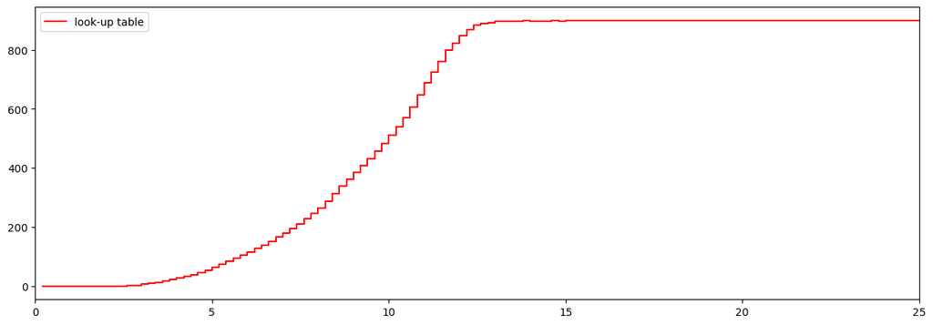

```python
# compare lookup table with data
plt.figure(figsize=(15,5))

# plot_wind_power(df)
s = plt.step(lutm.index.right, lutm.to_numpy(), color='r')

plt.legend(s, ['look-up table'], loc='upper left')
plt.xlim([0,25])
```

The plotted graph further illustrates clearly the connection between wind speed and power output. It can be noted that as the wind speed increases the power output also increases. This relationship holds up to a point as when the maximum power of the turbine is reached, higher winds speeds can no longer result in higher energy outputs due to the capacity limitations of the turbine.

## Question 1: How much energy is currently curtailed annually across the Orkney Isles?

### Turbine-level curtailment

The telemetry data from the Rousey turbine allows us to examine the level of curtailment in 2016 and 2017. We match up the wind speed of all the time points in the dataset with the ranges in the look-up table prepared in the previous section. Then, we create a new column "maxpower", which shows how much power the turbine would have generated if no curtailment occurred, given the wind speed range in that time point.

```python
# Defining wind speed intervals (bins)
bins = np.arange(0, 60, .2)

# Categorizing wind speed into intervals using defined bins
wcuts = pd.cut(wind.speed, bins)

# Adding wind speed interval column to 'wind' DataFrame
wind['speedrange'] = wcuts
```

```python
# Creating a DataFrame 'lookup' from 'lutm' with the speed range intervals and maximum power values.
lookup = pd.DataFrame(lutm).reset_index()

# Renaming the columns of the 'lookup' DataFrame to 'speedrange' and 'maxpower'.
lookup.columns = ['speedrange','maxpower']

# Merging the 'wind' DataFrame with the 'lookup' DataFrame based on the wind speed intervals.
turb = pd.merge(wind, lookup, on = 'speedrange')

# Sorting the 'turb' DataFrame in ascending order based on the 'time' column.
turb = turb.sort_values(['time'])

# Extracting the date and hour from the 'time' column and adding them as new columns 'date' and 'hour' in the 'turb' DataFrame.
turb['date'] = turb['time'].dt.date
turb['hour'] = turb['time'].dt.hour

# The resulting 'turb' DataFrame contains the merged data, sorted by time, with added columns for date and hour.
turb
```

|  | time | gen_power | setpt | speed | speedrange | maxpower | date | hour |
| --- | --- | --- | --- | --- | --- | --- | --- | --- |
| 0 | 2015-05-28 00:00:23 | 80.0 | 900.0 | 4.9 | (4.8, 5.0] | 53.68 | 2015-05-28 | 0 |
| 14868 | 2015-05-28 00:01:23 | 78.0 | 900.0 | 5.4 | (5.2, 5.4] | 73.69 | 2015-05-28 | 0 |
| 1 | 2015-05-28 00:02:23 | 52.0 | 900.0 | 4.9 | (4.8, 5.0] | 53.68 | 2015-05-28 | 0 |
| 30941 | 2015-05-28 00:03:23 | 57.0 | 900.0 | 4.6 | (4.4, 4.6] | 38.91 | 2015-05-28 | 0 |
| 30942 | 2015-05-28 00:04:23 | 54.0 | 900.0 | 4.6 | (4.4, 4.6] | 38.91 | 2015-05-28 | 0 |
| ... | ... | ... | ... | ... | ... | ... | ... | ... |
| 271204 | 2018-01-11 06:10:32 | 99.0 | 900.0 | 5.9 | (5.8, 6.0] | 104.54 | 2018-01-11 | 6 |
| 149110 | 2018-01-11 06:11:32 | 105.0 | 900.0 | 5.7 | (5.6, 5.8] | 93.72 | 2018-01-11 | 6 |
| 149111 | 2018-01-11 06:12:32 | 93.0 | 900.0 | 5.8 | (5.6, 5.8] | 93.72 | 2018-01-11 | 6 |
| 107662 | 2018-01-11 06:13:32 | 97.0 | 900.0 | 5.5 | (5.4, 5.6] | 83.32 | 2018-01-11 | 6 |
| 107663 | 2018-01-11 06:14:32 | 92.0 | 900.0 | 5.5 | (5.4, 5.6] | 83.32 | 2018-01-11 | 6 |

1065781 rows × 8 columns

We subset the moments between 2016-01-01 and 2017-12-31. In order to find the amount of energy lost, we need to identify the length of the time periods of curtailment. We assume that the time given in the dataset is the end of a period, and the time shown in the preceding row is the start of a period. We then convert the period in number of seconds. Finally, we subset the periods of curtailment, i.e. setpoint is lower than 900kW.

```python
# Creating a copy of the 'turb' DataFrame to work with
cur = turb.copy()

# Selecting data within a specific time range
cur = cur[(cur['time'] < pd.to_datetime('2018-01-01')) & (cur['time'] > pd.to_datetime('2016-01-01'))]

# Sorting the 'cur' DataFrame based on time
cur = cur.sort_values(['time'])

# Extracting the list of times from 'cur' DataFrame
clist = cur['time'][:-1].to_list()

# Inserting a starting time of '2015-12-31 23:59:34' at the beginning of the list
clist.insert(0,pd.to_datetime('2015-12-31 23:59:34'))

# Adding a new column 'start_time' to 'cur' DataFrame with the list of times
cur['start_time'] = clist

# Calculating the time period between 'start_time' and 'time' columns
cur['period'] = cur['time'] - cur['start_time']

# Converting the time period into seconds and adding a new column 'seconds' to 'cur' DataFrame
cur['seconds'] = [x.total_seconds() for x in cur['period']]

# Filtering out rows where the setpoint is less than 900
cur = cur[cur['setpt'] < 900]

# The resulting 'cur' DataFrame contains the selected data within the specified time range,
# sorted by time, with additional columns for start time, time period, and seconds, and filtered based on the setpoint value.
cur
```

|  | time | gen_power | setpt | speed | speedrange | maxpower | date | hour | start_time | period | seconds |
| --- | --- | --- | --- | --- | --- | --- | --- | --- | --- | --- | --- |
| 662260 | 2016-01-12 22:05:34 | 0.0 | 0.0 | 12.6 | (12.4, 12.6] | 883.75 | 2016-01-12 | 22 | 2016-01-12 22:04:34 | 0 days 00:01:00 | 60.0 |
| 662261 | 2016-01-12 22:06:34 | 0.0 | 0.0 | 12.6 | (12.4, 12.6] | 883.75 | 2016-01-12 | 22 | 2016-01-12 22:05:34 | 0 days 00:01:00 | 60.0 |
| 642835 | 2016-01-12 22:07:34 | 0.0 | 0.0 | 13.0 | (12.8, 13.0] | 892.40 | 2016-01-12 | 22 | 2016-01-12 22:06:34 | 0 days 00:01:00 | 60.0 |
| 551280 | 2016-01-12 22:08:34 | 0.0 | 0.0 | 12.3 | (12.2, 12.4] | 869.30 | 2016-01-12 | 22 | 2016-01-12 22:07:34 | 0 days 00:01:00 | 60.0 |
| 589742 | 2016-01-12 22:09:34 | 0.0 | 0.0 | 12.7 | (12.6, 12.8] | 889.75 | 2016-01-12 | 22 | 2016-01-12 22:08:34 | 0 days 00:01:00 | 60.0 |
| ... | ... | ... | ... | ... | ... | ... | ... | ... | ... | ... | ... |
| 804706 | 2017-12-19 03:23:32 | 0.0 | 0.0 | 9.3 | (9.2, 9.4] | 408.70 | 2017-12-19 | 3 | 2017-12-19 03:22:32 | 0 days 00:01:00 | 60.0 |
| 804707 | 2017-12-19 03:24:32 | 0.0 | 0.0 | 9.4 | (9.2, 9.4] | 408.70 | 2017-12-19 | 3 | 2017-12-19 03:23:32 | 0 days 00:01:00 | 60.0 |
| 355411 | 2017-12-19 03:25:32 | 0.0 | 0.0 | 9.0 | (8.8, 9.0] | 361.87 | 2017-12-19 | 3 | 2017-12-19 03:24:32 | 0 days 00:01:00 | 60.0 |
| 355412 | 2017-12-19 03:26:32 | 6.0 | 501.0 | 8.9 | (8.8, 9.0] | 361.87 | 2017-12-19 | 3 | 2017-12-19 03:25:32 | 0 days 00:01:00 | 60.0 |
| 605197 | 2017-12-20 21:03:32 | 799.0 | 771.0 | 13.7 | (13.6, 13.8] | 898.13 | 2017-12-20 | 21 | 2017-12-20 21:02:32 | 0 days 00:01:00 | 60.0 |

117940 rows × 11 columns

The resulting 'cur' DataFrame above contains the selected data within the specified time range, sorted by time, with additional columns for start time, time period, and seconds, and filtered based on the setpoint value.

```python
# Calculating the fraction of rows in 'cur' DataFrame where the time period is between 59 and 61 seconds.
len(cur[(cur.seconds <= 61) & (cur.seconds >= 59)]) / len(cur)
```

```
0.995506189587926
```

We see that for 99.6% of rows, the time period is between 59 and 61 seconds, i.e. roughly one minute. Next, we find the amount of curtailed power (loss_kw) in kW for each time period, which is the difference between "maxpower" (maximum potential power generated by the turbine at the given wind speed) and "gen_power" (actual power generated). In rare cases, the actual power generated > maximum potential power. In these cases, we set loss_kw as 0, as there is no loss of power due to curtailment.

We remove data points when the wind speed is fast enough for power production but there is no power, and capacity is above 0. The turbine is probably manually switched off here.

Finally, we calcuate the curtailed energy in kWh by multiplying loss_kw with the length of the time period (in hours).

```python
# Calculating the power loss (in kW) by subtracting the generated power from the maximum power for each row
cur['loss_kw'] = (cur['maxpower'] - cur['gen_power'])

# Setting negative power losses to 0 (since power loss cannot be negative)
cur['loss_kw'][cur['loss_kw'] < 0] = 0

# Removal of data points where no power is generated despite the setpoint above 0.
cur['loss_kw'][(cur['gen_power'] == 0) & (cur['setpt'] > 0)] = 0

# Calculating the energy loss (in kWh) by multiplying power loss (in kW) with the time period in hours
cur['loss_kwh'] = cur['loss_kw']*(cur['seconds']/3600)

# The resulting 'cur' DataFrame now includes columns for power loss in kW and energy loss in kWh.
cur
```

|  | time | gen_power | setpt | speed | speedrange | maxpower | date | hour | start_time | period | seconds | loss_kw | loss_kwh |
| --- | --- | --- | --- | --- | --- | --- | --- | --- | --- | --- | --- | --- | --- |
| 662260 | 2016-01-12 22:05:34 | 0.0 | 0.0 | 12.6 | (12.4, 12.6] | 883.75 | 2016-01-12 | 22 | 2016-01-12 22:04:34 | 0 days 00:01:00 | 60.0 | 883.75 | 14.729167 |
| 662261 | 2016-01-12 22:06:34 | 0.0 | 0.0 | 12.6 | (12.4, 12.6] | 883.75 | 2016-01-12 | 22 | 2016-01-12 22:05:34 | 0 days 00:01:00 | 60.0 | 883.75 | 14.729167 |
| 642835 | 2016-01-12 22:07:34 | 0.0 | 0.0 | 13.0 | (12.8, 13.0] | 892.40 | 2016-01-12 | 22 | 2016-01-12 22:06:34 | 0 days 00:01:00 | 60.0 | 892.40 | 14.873333 |
| 551280 | 2016-01-12 22:08:34 | 0.0 | 0.0 | 12.3 | (12.2, 12.4] | 869.30 | 2016-01-12 | 22 | 2016-01-12 22:07:34 | 0 days 00:01:00 | 60.0 | 869.30 | 14.488333 |
| 589742 | 2016-01-12 22:09:34 | 0.0 | 0.0 | 12.7 | (12.6, 12.8] | 889.75 | 2016-01-12 | 22 | 2016-01-12 22:08:34 | 0 days 00:01:00 | 60.0 | 889.75 | 14.829167 |
| ... | ... | ... | ... | ... | ... | ... | ... | ... | ... | ... | ... | ... | ... |
| 804706 | 2017-12-19 03:23:32 | 0.0 | 0.0 | 9.3 | (9.2, 9.4] | 408.70 | 2017-12-19 | 3 | 2017-12-19 03:22:32 | 0 days 00:01:00 | 60.0 | 408.70 | 6.811667 |
| 804707 | 2017-12-19 03:24:32 | 0.0 | 0.0 | 9.4 | (9.2, 9.4] | 408.70 | 2017-12-19 | 3 | 2017-12-19 03:23:32 | 0 days 00:01:00 | 60.0 | 408.70 | 6.811667 |
| 355411 | 2017-12-19 03:25:32 | 0.0 | 0.0 | 9.0 | (8.8, 9.0] | 361.87 | 2017-12-19 | 3 | 2017-12-19 03:24:32 | 0 days 00:01:00 | 60.0 | 361.87 | 6.031167 |
| 355412 | 2017-12-19 03:26:32 | 6.0 | 501.0 | 8.9 | (8.8, 9.0] | 361.87 | 2017-12-19 | 3 | 2017-12-19 03:25:32 | 0 days 00:01:00 | 60.0 | 355.87 | 5.931167 |
| 605197 | 2017-12-20 21:03:32 | 799.0 | 771.0 | 13.7 | (13.6, 13.8] | 898.13 | 2017-12-20 | 21 | 2017-12-20 21:02:32 | 0 days 00:01:00 | 60.0 | 99.13 | 1.652167 |

117940 rows × 13 columns

The tables below shows the curtailed energy each month and year in kWh, for the Rousey turbine. As shown in the table below, 767.1 MWh was lost in 2016 and 378.2 MWh was lost in 2017 for the Rousey turbine due to curtailment.

```python
# Grouping the 'cur' DataFrame by year and month of the 'time' column and calculating the sum of energy losses in kWh for each group
loss_month = cur.groupby([cur['time'].dt.year,cur['time'].dt.month])['loss_kwh'].sum()

# Converting the resulting series into a DataFrame
loss_month.to_frame()
```

| time | time | loss_kwh |
| --- | --- | --- |
| 2016 | 1 | 7604.330333 |
|  | 2 | 89.195625 |
|  | 3 | 23885.330497 |
|  | 4 | 107805.973342 |
|  | 5 | 58941.985278 |
|  | 6 | 57638.905000 |
|  | 7 | 51226.309525 |
|  | 8 | 105269.586047 |
|  | 9 | 112571.596217 |
|  | 10 | 116556.184714 |
|  | 11 | 121739.061614 |
|  | 12 | 3773.322414 |
| 2017 | 1 | 4871.306714 |
|  | 2 | 718.363000 |
|  | 3 | 22701.776572 |
|  | 4 | 6955.440667 |
|  | 5 | 31532.812158 |
|  | 6 | 59151.393186 |
|  | 7 | 50584.420108 |
|  | 8 | 60608.053589 |
|  | 9 | 57085.606567 |
|  | 10 | 44358.816056 |
|  | 11 | 16712.683283 |
|  | 12 | 22958.773167 |

```python
# Grouping the 'cur' DataFrame by year of the 'time' column and calculating the sum of energy losses in kWh for each year
loss_yr = cur.groupby([cur['time'].dt.year])['loss_kwh'].sum()

# Converting the resulting series into a DataFrame
loss_yr.to_frame()
```

| time | loss_kwh |
| --- | --- |
| 2016 | 767101.780606 |
| 2017 | 378239.445067 |

Marginal curtailment occurs when the turbine is curtailed but is first in the priority stack to receive extra export capacity. When a turbine is marginally curtailed, its output is trimmed. This is contrasted with full curtailment, where the turbine is fully disconnected and the setpoint is 0. It is important to determine when a turbine is marginally curtailed, as this is the only situation in which the extra local load would benefit the turbine through demand response.

```python
# Filtering the 'cur' DataFrame to include only rows where the setpoint is greater than 0 (indicating curtailment)
mar_cur = cur[cur['setpt'] > 0]

# The resulting 'mar_cur' DataFrame contains data for curtailed periods.
mar_cur
```

|  | time | gen_power | setpt | speed | speedrange | maxpower | date | hour | start_time | period | seconds | loss_kw | loss_kwh |
| --- | --- | --- | --- | --- | --- | --- | --- | --- | --- | --- | --- | --- | --- |
| 502458 | 2016-01-12 23:16:34 | 6.0 | 300.0 | 12.2 | (12.0, 12.2] | 848.58 | 2016-01-12 | 23 | 2016-01-12 23:15:34 | 0 days 00:01:00 | 60.0 | 842.58 | 14.043000 |
| 535193 | 2016-01-12 23:17:34 | 217.0 | 800.0 | 11.7 | (11.6, 11.8] | 798.43 | 2016-01-12 | 23 | 2016-01-12 23:16:34 | 0 days 00:01:00 | 60.0 | 581.43 | 9.690500 |
| 271972 | 2016-01-14 10:31:34 | 102.0 | 200.0 | 8.0 | (7.8, 8.0] | 245.62 | 2016-01-14 | 10 | 2016-01-14 10:30:34 | 0 days 00:01:00 | 60.0 | 143.62 | 2.393667 |
| 397776 | 2016-01-14 10:32:34 | 332.0 | 700.0 | 8.5 | (8.4, 8.6] | 312.99 | 2016-01-14 | 10 | 2016-01-14 10:31:34 | 0 days 00:01:00 | 60.0 | 0.00 | 0.000000 |
| 271973 | 2016-01-14 10:55:34 | 6.0 | 300.0 | 7.9 | (7.8, 8.0] | 245.62 | 2016-01-14 | 10 | 2016-01-14 10:54:34 | 0 days 00:01:00 | 60.0 | 239.62 | 3.993667 |
| ... | ... | ... | ... | ... | ... | ... | ... | ... | ... | ... | ... | ... | ... |
| 598480 | 2017-12-14 09:22:32 | 0.0 | 300.0 | 12.7 | (12.6, 12.8] | 889.75 | 2017-12-14 | 9 | 2017-12-14 09:21:32 | 0 days 00:01:00 | 60.0 | 0.00 | 0.000000 |
| 549739 | 2017-12-14 09:23:32 | 0.0 | 800.0 | 11.8 | (11.6, 11.8] | 798.43 | 2017-12-14 | 9 | 2017-12-14 09:22:32 | 0 days 00:01:00 | 60.0 | 0.00 | 0.000000 |
| 642068 | 2017-12-18 21:02:32 | 816.0 | 615.0 | 15.0 | (14.8, 15.0] | 898.12 | 2017-12-18 | 21 | 2017-12-18 21:01:32 | 0 days 00:01:00 | 60.0 | 82.12 | 1.368667 |
| 355412 | 2017-12-19 03:26:32 | 6.0 | 501.0 | 8.9 | (8.8, 9.0] | 361.87 | 2017-12-19 | 3 | 2017-12-19 03:25:32 | 0 days 00:01:00 | 60.0 | 355.87 | 5.931167 |
| 605197 | 2017-12-20 21:03:32 | 799.0 | 771.0 | 13.7 | (13.6, 13.8] | 898.13 | 2017-12-20 | 21 | 2017-12-20 21:02:32 | 0 days 00:01:00 | 60.0 | 99.13 | 1.652167 |

30513 rows × 13 columns

```python
# Grouping the 'mar_cur' DataFrame by year and month of the 'time' column, and calculating the sum of energy losses in kWh for each group
mar_loss_month = mar_cur.groupby([mar_cur['time'].dt.year,mar_cur['time'].dt.month])['loss_kwh'].sum()

# Converting the resulting series into a DataFrame
mar_loss_month.to_frame()
```

| time | time | loss_kwh |
| --- | --- | --- |
| 2016 | 1 | 346.211000 |
|  | 2 | 83.006958 |
|  | 3 | 11617.575161 |
|  | 4 | 23410.114006 |
|  | 5 | 6835.431925 |
|  | 6 | 6863.991792 |
|  | 7 | 3604.619178 |
|  | 8 | 13472.285500 |
|  | 9 | 1939.724000 |
|  | 10 | 21500.126214 |
|  | 11 | 40587.568806 |
|  | 12 | 304.499000 |
| 2017 | 1 | 38.000333 |
|  | 2 | 368.293000 |
|  | 3 | 12208.971239 |
|  | 4 | 4076.398167 |
|  | 5 | 5932.944392 |
|  | 6 | 7370.072056 |
|  | 7 | 7029.405222 |
|  | 8 | 9165.161658 |
|  | 9 | 14956.737067 |
|  | 10 | 9078.599333 |
|  | 11 | 2557.051000 |
|  | 12 | 9.074500 |

```python
# Grouping the 'mar_cur' DataFrame by year of the 'time' column and calculating the sum of energy losses in kWh for each year during curtailed periods
mar_loss_yr = mar_cur.groupby([mar_cur['time'].dt.year])['loss_kwh'].sum()

# Converting the resulting series into a DataFrame
mar_loss_yr.to_frame()
```

| time | loss_kwh |
| --- | --- |
| 2016 | 130565.153539 |
| 2017 | 72790.707967 |

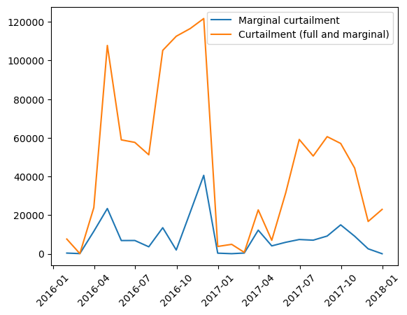

```python
# Plotting the monthly energy losses during curtailed periods and marginal monthly energy losses over the period from January 2016 to January 2018
plt.plot(pd.date_range(start='2016-01', end = '2018-01', freq='M'),mar_loss_month)
plt.plot(pd.date_range(start='2016-01', end = '2018-01', freq='M'),loss_month)

# Rotating the x-axis tick labels for better readability
plt.xticks(rotation = 45)

# Displaying the plot
plt.legend(['Marginal curtailment','Curtailment (full and marginal)'], loc ="best")
plt.show()
```

#### Total curtailment throughout the Orkney Isles

We assume that there is a total of 500 turbines throughout the Orkney isles. (https://theorkneynews.scot/2018/09/02/has-orkney-had-enough-of-wind-farms/)

In order to estimate the total curtailment loss, simply multiplying the loss of one turbine by 500 may not yield a highly accurate answer. This is due to the last-in-first-out nature of the curtailment: the last turbine that is connected to the grid are first out in the event of curtailment. Relatively newer turbines (many of these are community-owned) are placed lower in what is called the "priority stack", where the priority of access of the electric grid is lower. Hence, older turbines will face less curtailment loss than newer turbines.

Thus we take a different approach, by estimating the total energy output of the Orkney turbines and comparing that with the maximum potential energy output of those turbines. The difference of those numbers would be the curtailment loss, as this is represents the power that could have been generated, but ended up not being used by the Orkney locals or exported to the mainland.

## Exploratory Data Analysis: Demand Side

```python
# Loading the 'residential_demand' data from the CSV file, parsing the 'Timestamp' column as dates, and setting it as the index
resident_demand = pd.read_csv("residential_demand.csv", parse_dates=['Timestamp'], index_col = 0)

# Resetting the index of the DataFrame
resident_demand = resident_demand.reset_index()

# The resulting 'resident_demand' DataFrame contains the residential electricity demand data with an updated index.
resident_demand
```

|  | Timestamp | Demand_mean_kw | N_households |
| --- | --- | --- | --- |
| 0 | 2017-01-01 00:00:00 | 0.220106 | 5428 |
| 1 | 2017-01-01 00:30:00 | 0.205945 | 5429 |
| 2 | 2017-01-01 01:00:00 | 0.189090 | 5429 |
| 3 | 2017-01-01 01:30:00 | 0.173118 | 5429 |
| 4 | 2017-01-01 02:00:00 | 0.159051 | 5429 |
| ... | ... | ... | ... |
| 17563 | 2018-01-01 21:30:00 | 0.305905 | 10730 |
| 17564 | 2018-01-01 22:00:00 | 0.282975 | 10731 |
| 17565 | 2018-01-01 22:30:00 | 0.256498 | 10731 |
| 17566 | 2018-01-01 23:00:00 | 0.245829 | 10731 |
| 17567 | 2018-01-01 23:30:00 | 0.218793 | 10731 |

17568 rows × 3 columns

```python
len(resident_demand)
```

```
17568
```

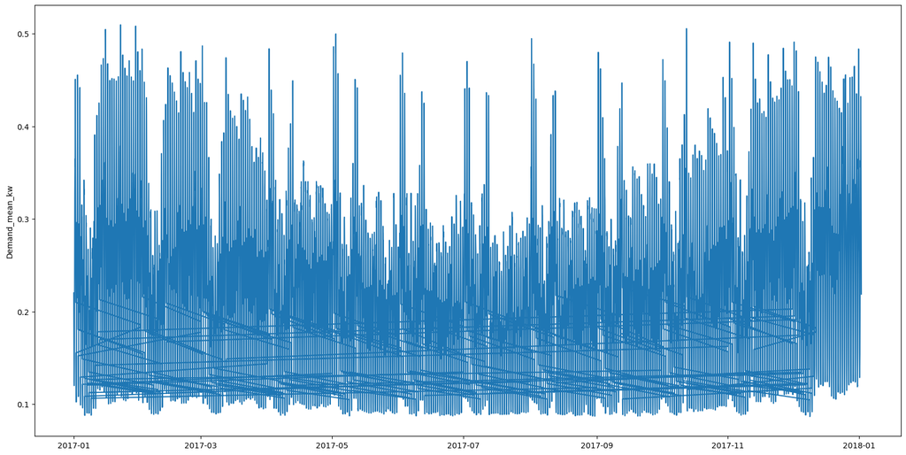

```python
# Yearly pattern
# Creating a figure with a larger size for better visibility
plt.figure(figsize=(20,10))

# Plotting the residential electricity demand over time
plt.plot(resident_demand.Timestamp, resident_demand['Demand_mean_kw'])

# Adding labels to the x-axis and y-axis
plt.ylabel('Demand_mean_kw')
plt.show()

# The plot shows the yearly pattern of residential electricity demand over time.
```

In general, we observe a yearly pattern in residential electricity demand. As expected, the demand reaches a low point during the summer months when households tend to use less electricity due to warmer temperatures. Additionally, we notice a recurring fluctuation in demand throughout the entire year, suggesting the presence of other patterns.

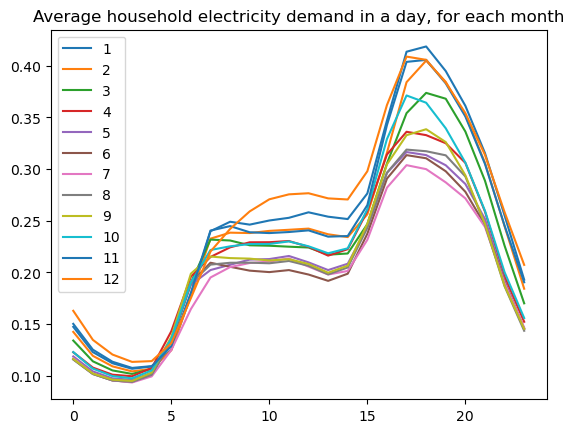

```python
# Adding hour, month, and date columns to the residential demand dataframe
resident_demand['hour'] = resident_demand['Timestamp'].dt.hour
resident_demand['month'] = resident_demand['Timestamp'].dt.month
resident_demand['date'] = resident_demand['Timestamp'].dt.date

# Calculating the average demand for each hour of the day, grouped by month
res_mean = resident_demand.groupby(['month','hour'])['Demand_mean_kw'].mean().reset_index()

# Plotting the average household electricity demand for each month
for i in range(1,13):
    dm = res_mean[res_mean.month == i]
    plt.plot(dm.hour, dm.Demand_mean_kw)

# Adding legend, title, and displaying the plot
plt.legend(range(1,13), loc ="best")
plt.title('Average household electricity demand in a day, for each month')
plt.show()
```

The plot reveals several interesting patterns in household electricity demand. Firstly, the lowest demand occurs in the month of July, which corresponds to the summer season when households typically require less electricity due to warmer temperatures. On the other hand, demand starts to increase rapidly after the month of October, indicating the onset of the winter season when more electricity is needed for heating and lighting.

Furthermore, the plot highlights a peak in demand at 6 pm, suggesting a surge in electricity consumption during the evening hours. This can be attributed to the typical daily routine of people returning home from work or school, resulting in higher demand.

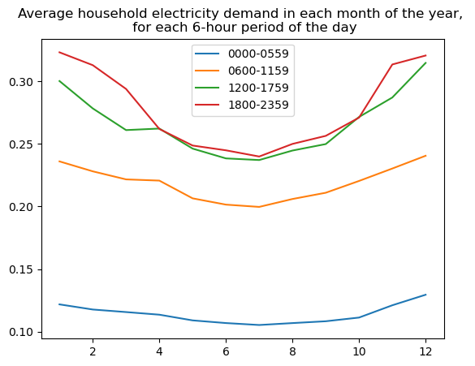

```python
# Grouping the average demand by 6-hour periods of the day
res_mean['hourrange'] = pd.cut(res_mean['hour'], [0,5,11,17,23],labels=False, right=True,
                              include_lowest=True)

# Calculating the average demand for each month and 6-hour period
res_mean2 = res_mean.groupby(['month','hourrange'])['Demand_mean_kw'].mean().reset_index()

# Plotting the average household electricity demand for each month and 6-hour period
for i in range(0,4):
    dm = res_mean2[res_mean2.hourrange == i]
    plt.plot(dm.month, dm.Demand_mean_kw)

# Adding legend, title, and displaying the plot
plt.legend(['0000-0559','0600-1159','1200-1759','1800-2359'], loc ="best")
plt.title('Average household electricity demand in each month of the year, \n for each 6-hour period of the day')
plt.show()
```

The plot clearly shows a spike in demand during the peak evening hours and a drop in demand during the morning hours, which is consistent with the patterns observed in the previous plot.

On the demand side, there are two elements: local load and exported power. Local load refers to the energy consumed by local households, which can be found in the resident demand dataset, but is limited to the full year 2017. Orkney can export up to 40 MW of power through the interconnection cable. We assume that energy is exported at full capacity of the interconnecters (given sufficient power generation).

On the supply side, we have the wind speeds related to the Rousay turbine between 2016 and 2017. We assume that the wind speed affecting all turbines are uniform. According to the Orkney Energy Audit 2019, the total installed capacity of wind turbine in Orkney is around 50MW. Of that 50MW, 45MW comes from large scale wind turbines (50kW or above), which in our case includes the Rousay turbine; 5MW comes from small scale wind turbines (below 50kW). Therefore, we multiply the maximum power generation of the Rousay turbine by 50000/900 = 55.56 to get the total maximum power generation throughout Orkney.

```python
# Resetting the index of the residential demand dataframe
nres = resident_demand.reset_index()

# Filtering the data for dates before January 1, 2018
nres = nres[nres['date'] < pd.to_datetime('2018-01-01')]

# Calculating the local load by multiplying the mean demand by a factor of 0.5 and scaling it by 10,000
nres['local_load'] = nres['Demand_mean_kw']*0.5*10000

# Grouping the data by date and hour, and summing the local load for each combination
nres_d = nres.groupby(['date','hour'])['local_load'].sum().reset_index()
nres_d
```

|  | date | hour | local_load |
| --- | --- | --- | --- |
| 0 | 2017-01-01 | 0 | 2130.257975 |
| 1 | 2017-01-01 | 1 | 1811.039790 |
| 2 | 2017-01-01 | 2 | 1533.533800 |
| 3 | 2017-01-01 | 3 | 1335.782830 |
| 4 | 2017-01-01 | 4 | 1222.002210 |
| ... | ... | ... | ... |
| 8755 | 2017-12-31 | 19 | 4152.226385 |
| 8756 | 2017-12-31 | 20 | 3607.293865 |
| 8757 | 2017-12-31 | 21 | 3175.643720 |
| 8758 | 2017-12-31 | 22 | 2779.908410 |
| 8759 | 2017-12-31 | 23 | 2545.537445 |

8760 rows × 3 columns

```python
# Calculating the total local load in 2017 by summing the local load values and converting it to gigawatt-hours (GWh)
print('Total local load in 2017 in GWh:',round(sum(nres_d.local_load)/1e6,2))
```

```
Total local load in 2017 in GWh: 19.18
```

```python
# Total exported energy = 40MW
nres_d['total_demand'] = nres_d['local_load'] + 40000

ngen_s = turb.groupby(['date','hour'])['maxpower'].mean().reset_index()
ds = pd.merge(nres_d, ngen_s, on=['date', 'hour'])
ds['month'] = [pd.to_datetime(x).month for x in ds['date']]

# Factor up the Rousay turbine's maximum potential power generation by (500/90)
ds['total_maxpower'] = ds['maxpower']*(50000/900)

# Curtailed power is equal to maximum potential power minus total demand.
# However, when that difference is less than zero, i.e. demand > maximum power from turbines, there is no curtailment.
ds['cur'] = ds['total_maxpower'] - ds['total_demand']
ds['cur'] = [0 if x < 0 else x for x in ds['cur']]

# Total power generation from Orkney turbines
# When total demand > maximum potential power, then the latter amount is generated.
# When maximum potential power > total demand, the latter is generated.
# Total power generation is therefore the minimum of the two.
ds['total_gen'] = ds[["total_demand", "total_maxpower"]].min(axis=1)
ds
```

|  | date | hour | local_load | total_demand | maxpower | month | total_maxpower | cur | total_gen |
| --- | --- | --- | --- | --- | --- | --- | --- | --- | --- |
| 0 | 2017-01-01 | 0 | 2130.257975 | 42130.257975 | 894.057000 | 1 | 49669.833333 | 7539.575358 | 42130.257975 |
| 1 | 2017-01-01 | 1 | 1811.039790 | 41811.039790 | 897.725000 | 1 | 49873.611111 | 8062.571321 | 41811.039790 |
| 2 | 2017-01-01 | 2 | 1533.533800 | 41533.533800 | 899.961915 | 1 | 49997.884161 | 8464.350361 | 41533.533800 |
| 3 | 2017-01-01 | 3 | 1335.782830 | 41335.782830 | 896.689452 | 1 | 49816.080670 | 8480.297840 | 41335.782830 |
| 4 | 2017-01-01 | 4 | 1222.002210 | 41222.002210 | 896.377333 | 1 | 49798.740741 | 8576.738531 | 41222.002210 |
| ... | ... | ... | ... | ... | ... | ... | ... | ... | ... |
| 8253 | 2017-12-31 | 19 | 4152.226385 | 44152.226385 | 821.406167 | 12 | 45633.675926 | 1481.449541 | 44152.226385 |
| 8254 | 2017-12-31 | 20 | 3607.293865 | 43607.293865 | 843.852000 | 12 | 46880.666667 | 3273.372802 | 43607.293865 |
| 8255 | 2017-12-31 | 21 | 3175.643720 | 43175.643720 | 566.259333 | 12 | 31458.851852 | 0.000000 | 31458.851852 |
| 8256 | 2017-12-31 | 22 | 2779.908410 | 42779.908410 | 236.673333 | 12 | 13148.518519 | 0.000000 | 13148.518519 |
| 8257 | 2017-12-31 | 23 | 2545.537445 | 42545.537445 | 87.517500 | 12 | 4862.083333 | 0.000000 | 4862.083333 |

8258 rows × 9 columns

```python
# Calculating the percentage of maximum potential energy being curtailed
print('Percentage of maximum potential energy being curtailed:',
      round(sum(ds['cur'])/sum(ds['total_gen'])*100, 2), "%")

# Calculating the curtailed energy throughout Orkney in 2017
print('Curtailment throughout Orkney in 2017 (in MW):', round(sum(ds['cur'])/(365*24*1e3),2))
print('Curtailed energy throughout Orkney in 2017 (in GWh):', round(sum(ds['cur'])/1e6,2))
```

```
Percentage of maximum potential energy being curtailed: 8.53 %
Curtailment throughout Orkney in 2017 (in MW): 1.92
Curtailed energy throughout Orkney in 2017 (in GWh): 16.79
```

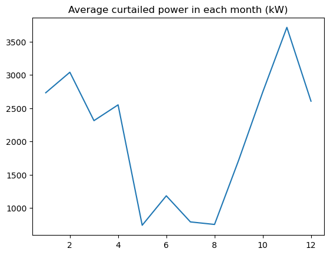

```python
# Grouping the average curtailed power by month
ds_cur_month = ds.groupby(['month'])['cur'].mean()

# Plotting the average curtailed power for each month
plt.plot(ds_cur_month.index, ds_cur_month)
plt.title('Average curtailed power in each month (kW)')
plt.show()
```

The plot reveals that the average power curtailed is the lowest during the summer months and the highest during the winter months.

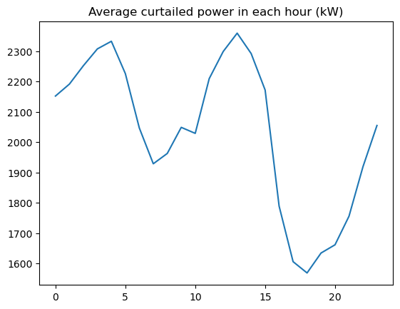

```python
# Grouping the average curtailed power by hour
ds_cur_hour = ds.groupby(['hour'])['cur'].mean()

# Plotting the average curtailed power for each hour
plt.plot(ds_cur_hour.index, ds_cur_hour)
plt.title('Average curtailed power in each hour (kW)')
plt.show()
```

## Questions 2 and 3: How much can curtailment be reduced by different levels of DR penetration?

Demand response involves shifting the energy usage and smoothing energy consumption around peak periods by altering consumer demand patterns through the right incentive mechanisms such as price discounts and in this case, smart heating devices. As shown in the plot above, the highest levels of curtailment happens during the early hours of the morning (around midnight to 5am) and during the midday (around 11am to 3pm). These are the periods when homes consume the least electricity. Since curtailment is directly related to the excess demand of energy, by using methods to increase demand during their non-peak hours, we can reduce curtailment. Storage heating devices are charged during periods of curtailment, such that heat is stored within. This heat energy can later be released to supplement the primary heating system when needed (Compton, 2020). We examine the extent to which curtailment can be reduced by such devices through the consumption of energy during times of curtailment. Three different scenarios are applied as to DR penetration: the proportion of households that install such devices and participate in the scheme.

### Assumptions for estimation of demand response effectiveness

1. Number of households that currently use electrical heating in Orkney

We assume that there are 10,000 households across Orkney. According to the 2011 Census in Scotland, about 40% of households use electric central heating. We assume that only households that have currently installed electric heating can install the smart heating devices to participate in demand response, serving as the secondary heating source for homes.

1. Specification and capacity of household DR storage heating devices

The technical capacities of the smart heating devices is one limiting factor of how much curtailment can be reduced. According to HSO, the heaters used in their trial (immersion and Dimplex heaters) had an average load of 2.3kW. Each household would have an average of 1.7 devices. These devices would operate for up to 7 hours a day (7/24 = 29.1% of the time). A further 50% haircut is applied to reflect fluctuations in distributions in curtailment, given the LIFO principle. At a given instance of curtailment, it is likely that not all turbines are curtailed, hence not all storage devices are switched on.

```python
hh = 10000
load = 2.3*1.7*0.5*(7/24)
elec = 0.4
dr_list = [0.1,0.5,0.9]
```

```python
ds_dr = ds.iloc[:,[0,1,5,7]]
drname = ['dr1','dr5','dr9']
curname = ['cur1','cur5','cur9']

for i in range(len(dr_list)):
    ds_dr[drname[i]] = [hh*load*dr_list[i]*elec if x > 0 else 0 for x in ds_dr['cur']]
    ds_dr[curname[i]] = ds_dr['cur'] - ds_dr[drname[i]]
    # The best case scenario is that curtailment for that hour is reduced to 0.
    ds_dr[curname[i]] = [0 if x < 0 else x for x in ds_dr[curname[i]]]

ds_dr
```

|  | date | hour | month | cur | dr1 | cur1 | dr5 | cur5 | dr9 | cur9 |
| --- | --- | --- | --- | --- | --- | --- | --- | --- | --- | --- |
| 0 | 2017-01-01 | 0 | 1 | 7539.575358 | 228.083333 | 7311.492025 | 1140.416667 | 6399.158692 | 2052.75 | 5486.825358 |
| 1 | 2017-01-01 | 1 | 1 | 8062.571321 | 228.083333 | 7834.487988 | 1140.416667 | 6922.154654 | 2052.75 | 6009.821321 |
| 2 | 2017-01-01 | 2 | 1 | 8464.350361 | 228.083333 | 8236.267027 | 1140.416667 | 7323.933694 | 2052.75 | 6411.600361 |
| 3 | 2017-01-01 | 3 | 1 | 8480.297840 | 228.083333 | 8252.214506 | 1140.416667 | 7339.881173 | 2052.75 | 6427.547840 |
| 4 | 2017-01-01 | 4 | 1 | 8576.738531 | 228.083333 | 8348.655197 | 1140.416667 | 7436.321864 | 2052.75 | 6523.988531 |
| ... | ... | ... | ... | ... | ... | ... | ... | ... | ... | ... |
| 8253 | 2017-12-31 | 19 | 12 | 1481.449541 | 228.083333 | 1253.366208 | 1140.416667 | 341.032874 | 2052.75 | 0.000000 |
| 8254 | 2017-12-31 | 20 | 12 | 3273.372802 | 228.083333 | 3045.289468 | 1140.416667 | 2132.956135 | 2052.75 | 1220.622802 |
| 8255 | 2017-12-31 | 21 | 12 | 0.000000 | 0.000000 | 0.000000 | 0.000000 | 0.000000 | 0.00 | 0.000000 |
| 8256 | 2017-12-31 | 22 | 12 | 0.000000 | 0.000000 | 0.000000 | 0.000000 | 0.000000 | 0.00 | 0.000000 |
| 8257 | 2017-12-31 | 23 | 12 | 0.000000 | 0.000000 | 0.000000 | 0.000000 | 0.000000 | 0.00 | 0.000000 |

8258 rows × 10 columns

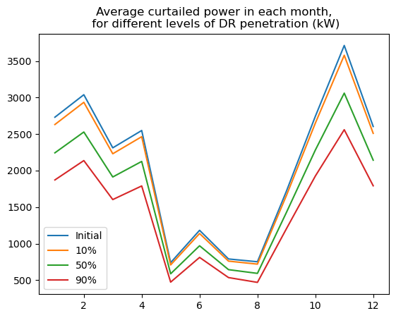

```python
ds_cur_month = ds_dr.groupby(['month'])['cur'].mean()
plt.plot(ds_cur_month.index, ds_cur_month)

for i in range(len(dr_list)):
    ds_cur_month = ds_dr.groupby(['month'])[curname[i]].mean()
    plt.plot(ds_cur_month.index, ds_cur_month)
    plt.title('Average curtailed power in each month,\n for different levels of DR penetration (kW)')

plt.legend(['Initial','10%','50%','90%'], loc ="lower left")
```

The plot of average curtailed power in each month for different levels of demand response (DR) penetration shows that there is lower average curtailed power during the summer months, the lower average curtailed power during summer months in the plot indicates a combination of reduced electricity demand, behavioral patterns, increased renewable energy generation, and tailored demand response strategies.

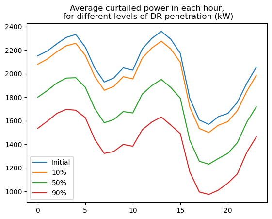

```python
ds_cur_hour = ds_dr.groupby(['hour'])['cur'].mean()
plt.plot(ds_cur_hour.index, ds_cur_hour)

for i in range(len(dr_list)):
    ds_cur_hour = ds_dr.groupby(['hour'])[curname[i]].mean()
    plt.plot(ds_cur_hour.index, ds_cur_hour)
    plt.title('Average curtailed power in each hour,\n for different levels of DR penetration (kW)')

plt.legend(['Initial','10%','50%','90%'], loc ="lower left")
```

The plot of average curtailed power for different levels of demand response (DR) penetration shows that the initial level of DR penetration results in the highest curtailed power, while the 90% level of DR penetration corresponds to the lowest curtailed power.

This indicates that as the level of DR penetration increases, there is a noticeable reduction in curtailed power. The plot demonstrates the effectiveness of demand response measures in mitigating curtailment, with higher levels of DR penetration leading to more significant reductions in curtailed power.

By comparing the different levels of DR penetration, it becomes evident that increasing the participation of households in DR programs can yield substantial benefits in terms of curtailment reduction. The plot provides valuable insights for decision-making, suggesting that higher levels of DR penetration are more effective in minimizing curtailed power.

#### Overall curtailment reduction in different DR penetration scenarios

```python
reduc = list()
reduc_pc = list()

for i in range(len(drname)):
    r = sum(ds_dr[drname[i]])
    rgwh = round(r / 1e6, 3)
    pc = round(r * 100 / sum(ds_dr.cur),1)
    reduc.append(rgwh)
    reduc_pc.append(pc)

dr_effect = pd.DataFrame({'DR penetration (%)' : [round(x*100) for x in dr_list],
                          'No. of participating households' : [round(x*hh*elec) for x in dr_list],
                          'Curtailment reduction (GWh)' : reduc,
                          'Curtailment reduction (%)' : reduc_pc})
dr_effect
```

|  | DR penetration (%) | No. of participating households | Curtailment reduction (GWh) | Curtailment reduction (%) |
| --- | --- | --- | --- | --- |
| 0 | 10 | 400 | 0.606 | 3.6 |
| 1 | 50 | 2000 | 3.028 | 18.0 |
| 2 | 90 | 3600 | 5.450 | 32.5 |

From the given data on different levels of demand response (DR) penetration and their corresponding curtailment reductions, the following insights can be derived:

Increasing DR penetration leads to higher curtailment reduction: As the DR penetration increases from 0% to 90%, there is a clear trend of higher curtailment reduction. This suggests that greater participation of households in DR programs can effectively reduce curtailed power.

Significant curtailment reduction achieved even with low DR penetration: Even at a low DR penetration of 10%, there is a noticeable curtailment reduction of 0.61 GWh, representing approximately 3.6% of the initial curtailed power. This indicates that even a small level of DR participation can yield tangible benefits in terms of curtailment reduction.

Scaling up DR penetration yields substantial curtailment reduction: The data shows that with 50% DR penetration, the curtailment reduction increases to 3.03 GWh, accounting for around 18% of the initial curtailed power. At 90% DR penetration, the curtailment reduction further rises to 5.45 GWh, representing approximately 32.5% of the initial curtailed power. These numbers demonstrate the potential for significant curtailment reduction when a majority of households participate in DR programs.

Curtailment reduction is proportional to the number of participating households: The data also highlights the relationship between the number of participating households and curtailment reduction. As the number of participating households increases from 400 to 2000, there is a corresponding increase in curtailment reduction. This suggests that the active involvement of more households in DR programs can lead to greater curtailment reduction.

These insights underscore the importance and effectiveness of demand response measures in reducing curtailment and optimizing energy consumption. They provide evidence that scaling up DR penetration and encouraging more households to participate can contribute significantly to curtailment reduction efforts, leading to a more efficient and sustainable energy system.

## Cost Benefit Analysis

The second aspect to consider is that the estimates of curtailment reduction do not account for any practical limitations when it comes to the overall implementation of the project. It should be recognised that a number of factors could impact this estimate, which have not been accounted for in our model thus far.

Such considerations include but are not limited to the following:

**1) Consumers' manual intervention**

It is known that while the installed smart devices would automatically switch on when supply is higher in order to enable the DR, a feature which allows for user intervention and manual control exists and, as such, there is a possibility that some users will switch off the devices present in their households, depending on their actual heating needs. This in turn may impact the overall curtailment reduction achieved in practice.

**2) IoT communication errors/system disruptions**

There is a risk that the IoT devices malfunction, lose connection to the smart devices installed in households or transmit information with a delay. Communication errors can occur at individual heater levels or between individual heaters and the turbines (HSO Project Report, 2016-2018). As such, this may also result in lost curtailment opportunities albeit for short periods of time, assuming that there is continuous and effective monitoring of the smart system enabling DR management.

**3) System efficiency for detecting curtailment events**

According to the HSO Report (2016-2018), the system efficiency for detecting and dispatching load during curtailment events differs based on the number of turbines involved. Specifically, the higher the number of turbines the higher the efficiency. Given the number of turbines considered in our assessment (36), we will assume an efficiency of 90%, in line with the figure provided by the report for over 20 turbines.

In light of the above potential limitations and given a more conservative approach is preferred when it comes to an overall revenue estimate, we deem an adjustment factor of 15% adequate to reduce the curtailment potential, in order to construct a more realistic profit estimate that accounts for the limitations mentioned above, which are not built in the model.

As such, the curtailment figures we will take forward in our revenue estimate analysis in the 3 scenarios are: 0.52 GWh, 2.58GWh and 4.63GWh.

Once the energy curtailment potential has been established and the adjustment factor applied, we turn to converting this into a financial estimate in terms of potential additional revenue streams.

**Yearly revenue opportunity estimates based on 2017 overall estimated potential curtailment reduction figures in the 3 DR response scenarios:**

For the purposes of these calculations we will limit our analysis to the year 2017 estimated curtailment potential and assume that the additional revenue streams came strictly from the curtailment reductions that could be realised through the installation of smart devices. We will use the overall curtailment reduction potential figures obtained at an aggregate level for the Orkney Isles.

As such, in the 3 scenarios of DR penetration, the yearly revenue estimates would be caluclated as follows:

**Yearly Revenue = Overall curtailment reduction at corresponding % DR penetration rate x 0.85 (model adjustment factor) x 0.15p/KWh**</b>

```python
# Estimating yearly revenue figures in the 3 scenarios of DR penetration (10%, 50% and 90%)
rev1 = reduc[0] * 1e6 * 0.85 * 0.15
rev2 = reduc[1] * 1e6 * 0.85 * 0.15
rev3 = reduc[2] * 1e6 * 0.85 * 0.15

print('Estimate 1 (10% DR penetration) = £', rev1)
print('Estimate 2 (50% DR penetration) = £', rev2)
print('Estimate 3 (90% DR penetration) = £', rev3)
```

```
Estimate 1 (10% DR penetration) = £ 77265.0
Estimate 2 (50% DR penetration) = £ 386070.0
Estimate 3 (90% DR penetration) = £ 694875.0
```

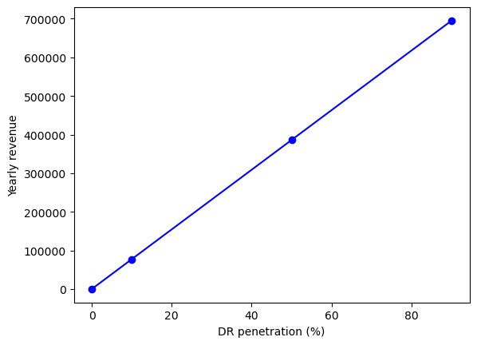

```python
# Plotting the relationship between yearly revenue estimates and % of DR penetration

x = [0,10,50,90]
revs = [0,rev1,rev2,rev3]
plt.plot(x, revs, '-bo')
plt.xlabel("DR penetration (%)")
plt.ylabel("Yearly revenue")
```

As shown in the figure above, the DR penetration rate has a roughly linear relationship with the amount of curtailment reduction, and hence with revenue from electricity generation. More precisely, for each 1% increase in DR penetration, the additional revenue is about £7,726.

**Revenue Estimate Limitations**

1) For the above estimate we have not taken into account any potential restrictions that may apply for example in terms of the maximum amount of mitigated curtailment any one individual device could contribute with.

2) The 15% reduction in the overall curtailment potential has been applied to account for system inefficiencies and the other limitations mentioned above, however it should be noted that not all scenarios which could impact the curtailment potential reductions in a negative way have been considered (i.e. extreme disruptions or significant reductions in wind speed due to climate change). Also, the analysis is based on estimates for one year only, which is a relatively limited time span.

3) The estimated figure for the value of avoided curtailment per KWh is based on a 2017 estimate, which would be subject to change year on year, based on energy price fluctuations.

4) Finally, while for the purposes of cost-benefit analysis we have computed a yearly revenue estimate, a more comprehensive multi year assessment would be required to determine the potential revenue estimation over a number of years, accounting for changes in prices, demand fluctuations, overall power capacity of the turbines in Orkney and a potential gradual increase in DR penetration.

## Cost Component Estimates

On the cost side of the equation, multiple cost components have to be considered from Kaluza's and HSO perspective. All price estimates were sourced from the HSO report (2016-2018) which tackles the exact same scenario as in our analysis but at a smaller scale project. Hence, the figures are deemed adequate to use in our analysis.

Specifically, the following are the cost components considered and assumptions made.

1) **Costs associated with the turbines** - both one off costs in the implemenetation/set up year and ongoing yearly operational costs are evaluated. These include costs related to ongoing software engineering development and support, the capital investment for the IOT equipment to be installed for each of the turbines and software development costs, both one off and ongoing yearly costs for further development and maintenance/software support.

In order to proceed to determine a cost estimate for turbine related costs that depend on the number of turbines, first an assumption must be made in relation to the number of turbines that participate in the project. For our calculation, we will proceed under the assumption that 36 turbines will have the IoT software installed. This is aligned to the number of large capacity turbines (i.e. installed capacity greater than 50kW) in Orkney, which account overall for the 90% of the total capacity of local turbines (around 45 out of 50MW) (Orkney Energy Audit, 2019). This is a cost efficient approach given one of the highest cost components is the turbine related cost dependent on the number of turbines. By installing the devices only on the turbines with the highest capacity, we achieve set up cost efficiencies while maximising the amount of potential curtailment reduction.Given the high costs per turbine, it would not be efficient to install these devices on the other 400+ small size turbines, as the curtailment reduction potential of these is only 10% of the total potential curtailment reduction (based on their capacity). This assumption is also supported by the fact that even in the best case scenario of 90% DR penetration, the maximum curtailment reduction achieved is 32.5%. THe only limitation in this scenario is the fact that there is a possibility that some of the smaller turbines are curtailed before the larger turbines are. However, as per the 2019 Energy Audit of Orkney Isles, most of both large and small capacity turbines were installed during the period 2010-2014, in similar proprotions (Orkney Energy Audit, 2019). As such, it is reasonable to assume that the 'priority-stack' principle will impact in similar proportions both small and large turbines.

2) **Costs associated with household devices** - these costs relate to the procurement, installation, maintenance of devices, software cloud services required on an ongoing basis for data storage and management and software support services.

#### Cost Component Estimates (turbine related costs)

| Cost Components (Turbine Related) | Estimated Amount/unit (£) | Total Cost (assuming 36 turbines join scheme) |
| --- | --- | --- |
| **Costs dependent on turbine count** |  |  |
| IoT capital investment (one off) | 300/turbine | 10800 |
| IoT installation (one off) | 2 day contractor hire at 30/hour for 8 hours/tubine | 17280 |
| IoT software development support (one off) | 2 FTEs @£60000 p.a. | 120000 |
| **Costs independent of turbine count** |  |  |
| Software engineering development and support costs (ongoing) | 1 FTEs @60000 p.a. | 60000 |
| IoT maintenance costs (ongoing) | assuming 5% device failure yearly, 8h contractor at 30/h | 432 |
| **Total cost estimate (one off in set up year)** |  | **148080** |
| **Total yearly running cost estimate (yearly/ongoing)** |  | **60432** |

```python
# Calculating Turbine related initial set up cost and ongoing yearly operational costs
turb_init_cost = 300*36 + 2*30*8*36 + 2*60000
turb_yr_cost = 60000 + 0.05*36*8*30
print('Turbine initial setup cost: £',turb_init_cost)
print('Turbine yearly ongoing cost: £',turb_yr_cost)
```

```
Turbine initial setup cost: £ 148080
Turbine yearly ongoing cost: £ 60432.0
```

It can be noted the the highest cost component for the turbine related costs is the initial set up cost, which is **£148,080**. Once the smart devices are installed on the turbines, the yearly ongoing operational cost is **£60,432**.

#### Cost Component Estimates (household devices and rebate related costs)

| Cost Components (Device Related) | Estimated Amount/unit (£) |
| --- | --- |
| Smart device capital investment (one off) | 100/device x 4000 (total eligible households) x DR % x 1.7 (avg devices/hh) |
| Smart device home installation (one off) | 3h 1 contractor @ £30 |
| Smart device maintenance (ongoing) | assuming 5% device failure yearly, 2h contractor at £30/h |
| Kaluza cloud platform costs (ongoing) | 22k/100 devices, 45k/1000, 112k/5000 and 224k/10000 p.a. |
| Software engineering support (ongoing) | 10% FTE at £60000 p.a. for 100 devices, increasing with 10% for every 1000 devices |
| Rebates to households(one off) | 0.06p/KWh x estimated overall curtailment reduction per scenario (post -15% adjustment) |

```python
# Function for generating the device-related initial set up costs and ongoing yearly costs
def dev_init_cost(pr):
    dev_count = pr*4000*1.7
    cap_inv = 100*dev_count
    install = 3*30*4000*pr
    rebate = 0.06*reduc[0]*(pr/0.1)* 1e6 * 0.85
    return cap_inv + install + rebate

def dev_yr_cost(pr):
    dev_count = pr*4000*1.7
    maintain = dev_count*0.05*2*30
    if dev_count < 1000:
        cloud = 45000
    elif dev_count < 5000:
        cloud = 112000
    else: cloud = 224000
    software = 6000 + 60000*0.1*(dev_count-1000)/1000
    return maintain + cloud + software
```

```python
# Calculating device-related costs in each of the 3 scenarios
dr_list = [0.1,0.5,0.9]
pd.DataFrame({'DR penetration (%)':[round(x*100) for x in dr_list],
              'Initial cost':[dev_init_cost(x) for x in dr_list],
             'Yearly cost':[dev_yr_cost(x) for x in dr_list]})
```

|  | DR penetration (%) | Initial cost | Yearly cost |
| --- | --- | --- | --- |
| 0 | 10 | 134906.0 | 51120.0 |
| 1 | 50 | 674530.0 | 142600.0 |
| 2 | 90 | 1214154.0 | 279080.0 |

We note the that initial set up cost related to household device installation is the highest value cost component related to household devices, similar to the turbine costs. Furthermore, it can be noted that both the initial costs and ongoing yearly costs related to devices very significantly based on the % of DR penetration. Higher DR penetration however also comes with much higher yearly revenue streams.

## Project Valuation - Cash Flow and Net Present Value Analysis

In order to evaluate the project we will conduct a net present value analysis for each of the 3 scenarios first, using the yearly revenue and overall cost estimates. We will make the simplifying assumption that year on year the revenues remain constant. We also assume that the yearly/ongoing cost component remains constant over the years.

We assume a discount factor of 2% and a project lifetime of 10 years. The timeframe is based on timelines of similar large scale investment projects in the electric energy industry.

We will first generate the yearly cash flows for each of the 3 scenarios. Using the discount factor we will then compute the NPV values of the project in each scenario.

```python
# Setting up vectors for yearly revenue streams
rev_s1 = np.repeat(rev1,10)
rev_s2 = np.repeat(rev2,10)
rev_s3 = np.repeat(rev3,10)

# Setting up vectors for set up costs and ongoing yearly costs
set_up_cost_s1 = np.repeat(0,10)
set_up_cost_s1[0] = turb_init_cost + dev_init_cost(0.1)
set_up_cost_s2 = np.repeat(0,10)
set_up_cost_s2[0] = turb_init_cost + dev_init_cost(0.5)
set_up_cost_s3 = np.repeat(0,10)
set_up_cost_s3[0] = turb_init_cost + dev_init_cost(0.9)

ongoing_cost_s1 = np.repeat(turb_yr_cost + dev_yr_cost(0.1),10)
ongoing_cost_s2 = np.repeat(turb_yr_cost + dev_yr_cost(0.5),10)
ongoing_cost_s3 = np.repeat(turb_yr_cost + dev_yr_cost(0.9),10)

discount_factor = 0.02
```

```python
# Yearly cash flow generation
CF_s1 = rev_s1 - set_up_cost_s1 - ongoing_cost_s1
CF_s2 = rev_s2 - set_up_cost_s2 - ongoing_cost_s2
CF_s3 = rev_s3 - set_up_cost_s3 - ongoing_cost_s3
CF = pd.DataFrame([CF_s1, CF_s2, CF_s3], columns = ["Year 1 (set up year)", "Year 2", "Year 3", "Year 4", "Year 5", "Year 6", "Year 7", "Year 8", "Year 9", "Year 10"])
CF.index = ["Scenario 1 (10% DR)", "Scenario 2 (50% DR)", "Scenario 3 (90% DR)"]
CF
```

|  | Year 1 (set up year) | Year 2 | Year 3 | Year 4 | Year 5 | Year 6 | Year 7 | Year 8 | Year 9 | Year 10 |
| --- | --- | --- | --- | --- | --- | --- | --- | --- | --- | --- |
| Scenario 1 (10% DR) | -317273.0 | -34287.0 | -34287.0 | -34287.0 | -34287.0 | -34287.0 | -34287.0 | -34287.0 | -34287.0 | -34287.0 |
| Scenario 2 (50% DR) | -639572.0 | 183038.0 | 183038.0 | 183038.0 | 183038.0 | 183038.0 | 183038.0 | 183038.0 | 183038.0 | 183038.0 |
| Scenario 3 (90% DR) | -1006871.0 | 355363.0 | 355363.0 | 355363.0 | 355363.0 | 355363.0 | 355363.0 | 355363.0 | 355363.0 | 355363.0 |

```python
# Calculating the NPV of the project assuming different levels of DR penetration (10%, 50% and 90%)
npv_s1 = npf.npv(discount_factor, CF_s1)
npv_s2 = npf.npv(discount_factor, CF_s2)
npv_s3 = npf.npv(discount_factor, CF_s3)
```

```python
# Creating data frame containing the NPV values
NPV = pd.DataFrame ([npv_s1, npv_s2, npv_s3], columns = ["NPV"])
NPV.index = ["Scenario 1 (10% DR)", "Scenario 2 (50% DR)", "Scenario 3 (90% DR)"]
```

```python
pd.set_option('display.float_format', lambda x: '%.2f' % x)
NPV
```

|  | NPV |
| --- | --- |
| Scenario 1 (10% DR) | -597131.61 |
| Scenario 2 (50% DR) | 854427.48 |
| Scenario 3 (90% DR) | 1893685.92 |

## Discussion of Financial Analysis Results

In scenario 1 (10% DR penetration) it can be noted that there is a constant negative cash flow aver the 10 years, with a negative cash flow of **£-317,273** in year 1, followed by a negative cash flow of **£34,287**. This is not surprising as the yearly operating costs are higher than the estimated yearly revenue when there is only 10% DR penetration and the initial set up cost is also an extremely large component of the overall cost. The NPV value of the project in this scenario is negative at **£-597131**.

The projections look much more optimistic in scenario 2 (50% DR penetration), scenrio in which we have a negative cash flow in the set up year ( **£-639,572** followed by positive cash flows year on year of **£183,038**. Overall, the estimated project NPV in scenario two is **£854,427.48**, which means that the project is worth investing, provided all assumptions hold.

Finally, in the 90% DR response scenario the projects seems to be even more profitable, with an estimated NPV over a 10 year period of **£1,893,685.92**. However, we also observe that this scenario involves a very large set up cost, which results in a significant cash outflow in year 1 of **£-1,006,871**, followed by steady positive cash flows of **£355,363** yearly.

Overall, based on the analysis conducted, we find that the project is worth undertaking when there are significant DR penetration rates (50% and 90% respectively). At the same time, low DR rates mean that the project is not worth investing in and it would generate a loss on a yearly basis.

Furthermore, we observe that higher the DR rate, higher the NPV of the projects, with a significant increase in NPV between scenarios 2 and 3. This is intuitive and indicates that the project profitability increases with the increase in the DR penetration rate. This is expected given the highest cost component is the fixed set up cost, while the year on year cost has a smaller weight and given that we have assumed that regardless of the DR penetration rate, 36 turbines will be equipped with the necessary smart systems. At the same time, higher penetration results in higher revenues year on year.

Upon this initial analysis, we further our assessment aiming to identify the minimum level of DR penetration at which the project would generate a positive NPV.

```python
# Simulating various increments of curtailment reduction for 10000 different levels of DR penetration

discount_factor = 0.02
npv_list = list()
dr_list = np.linspace(0,1,10000)

for i in range(len(dr_list)):
    dr_amount = [hh*load*dr_list[i]*elec if x > 0 else 0 for x in ds_dr['cur']]
    total_dr = round(sum(dr_amount)/1e6,3)
    rev = total_dr * 1e6 * 0.85 * 0.15
    revs = np.repeat(rev,10)
    set_up_cost = np.repeat(0,10)
    set_up_cost[0] = turb_init_cost + dev_init_cost(dr_list[i])
    ongoing_cost = np.repeat(turb_yr_cost + dev_yr_cost(dr_list[i]),10)
    CF = revs - set_up_cost - ongoing_cost
    npv_list.append(npf.npv(discount_factor, CF))
```

```python
# Generating the corresponding NPV values at various levels of DR penetration
npv_dt = pd.DataFrame({'DR': [x*100 for x in dr_list],
                       'NPV': npv_list,
                      'Initial setup cost': init_cost_list,
                      'Ongoing yearly cost': ongoing_cost_list})
npv_dt
```

|  | DR | NPV | Initial setup cost | Ongoing yearly cost |
| --- | --- | --- | --- | --- |
| 0 | 0.00 | -1114072.94 | 148080.00 | 105432.00 |
| 1 | 0.01 | -1113094.83 | 148214.92 | 105438.12 |
| 2 | 0.02 | -1113285.91 | 148349.84 | 105444.24 |
| 3 | 0.03 | -1112308.81 | 148484.76 | 105450.36 |
| 4 | 0.04 | -1112499.88 | 148619.68 | 105456.48 |
| ... | ... | ... | ... | ... |
| 9995 | 99.96 | 2407887.01 | 1496600.32 | 345607.52 |
| 9996 | 99.97 | 2408864.12 | 1496735.24 | 345613.64 |
| 9997 | 99.98 | 2408673.04 | 1496870.16 | 345619.76 |
| 9998 | 99.99 | 2409650.15 | 1497005.08 | 345625.88 |
| 9999 | 100.00 | 2410627.25 | 1497140.00 | 345632.00 |

10000 rows × 4 columns

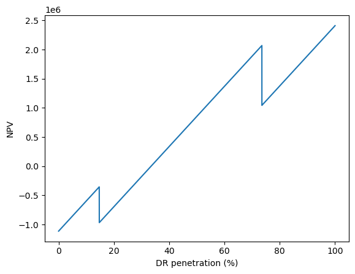

```python
# Plotting the relationship between DR % penetration and estimated project NPV
plt.plot(npv_dt.DR, npv_dt.NPV)
plt.xlabel('DR penetration (%)')
plt.ylabel('NPV')
```

By visually inspecting the plot, we note that the % of DR penetration at which the NPV value of the project turns positive lies somehwere between 30% and 40%, approximately at around 35%.

```python
# Calculating the exact % of DR penetration at which the NPV value turns positive
pos_npv_dt = npv_dt[npv_dt['NPV'] > 0]
zeronpv = pos_npv_dt.DR.iloc[np.argmin(pos_npv_dt.NPV)]
print('Minimum DR penetration require for NPV to be positive (%):', round(zeronpv,1))
```

```
Minimum DR penetration require for NPV to be positive (%): 33.5
```

```python
min_households = 4000*0.335
print ("The minimum number of households required to sign up for the project to generate a positive NPV is", min_households)
```

```
The minimum number of households required to sign up for the project to generate a positive NPV is 1340.0
```

Upon calculating, we find that:

- The minimum % of DR penetration required for the project to be viable (i.e. have a non-negative NPV) is **33.5%**.
- The equivalent number of households based on the set up of our analysis is **1340**.

  which is essentially 33.5% of the 4000 households we assumed have electrical heating and would be eligible for enrollment into the DR management programme.

## Consumer Benefits

**1) Rebated Electricity**  
The income generated for the participating generator by letting the turbine continue its operation, when it would have otherwise been switched off due to curtailment, is a major perk. As a result, the energy that was generated was offered to the consumers at on a rebate. This discounted energy was primarily used for running the heating systems, thus providing affordable warmth for vulnerable consumers as the island is known to have a high fuel poverty at a whopping 63%. HSO employed an average rebate of 5 p/kWh thus creating value for the local community in a more sustainable way.

**2) HSO devices - efficiency**  
A bespoke smart heating solution is designed for each household, based on their available heating systems making the island ahead of the rest of the country in the adoption of green energy. This potentially helps Orkney move away from their dependence on the gas grid to heating community buildings, schools, care homes with cheap electricity.

The HSO devices installed were highly energy efficiency in comparison to the older devices, the newer devices were estimated to be at least 20% more efficient. According to the HSO final report for every 1 kWh consumed by new heaters and boilers installed for the trial purpose were able to save 1.25 kWh from the older devices. During the HSO trial run when about 72 properties participated in the project, the fossil fuels usage across project properties witnessed a considerable decrease. owing to the previously mentioned efficiency of the HSO devices, about 4700 litres of oil and 8000kg of coal and wood were displaced with green energy.

**3) Community**  
The self-funded HSO project offered employment opportunities within the community of Orkney for a sustained period of time thus allowing HSO's staff to gain useful and transferrable skills that can helped them participate in the subsequent projects like SMILE and ReFLEX, giving opportunity for the company with the income to continue trading well beyond their initial funding.

## Environmental Impact

The analysis thus far confirmed that in the event the project is launched and manages to achieve a high enough DR % penetration rate, there will be financial benefits for turbine owners, which would achieve additional yearly revenues from the reduction of energy curtailment. In addition, there will be a financial benefit to the consumers, who will enjoy discounted energy prices during the project set up year for part of the energy they consume as well as more efficient heating systems in their homes due to the smart device set ups (as this implicitly will result in less overall household consumption and hence a lower total energy cost). However, there is one additional key benefit of this project, which is the potential positive environmental impact.

Specifically, producing more green energy means that a **CO2** footprint reduction is achieved.

According to the 2022 Report on UK greenhouse gas emissions, in 2022 the average figure for emissions per unit of fossil fuel based energy were estimated to be around 532 tonnes of CO2/GWh (2022, UK Department for Energy Securty & Net Zero).

At the same time, according to Energy.Gov (2022), green, low carbon wind energy generates 11 tonnes of CO2 emissions per GWh.

Assuming that any energy that would have been curtailed without the DR mechanism in place would have been substituted most likely by fossil fuel based energy and using the above figures, we estimate savings in carbon emissions of **521 tonnes/GWh**.

Turning to the various DR % penetration rates, in the two scenarios when the project would generate a positive NPV (50% and 90%), the amount of extra green energy produced through curtailment avoidance would translate into reductions of CO2 emissions of **1344.18 t** and **2412.23 t** respectively on a yearly basis (after the adjustment factor on overall curtailment reduction potential is applied). Of course, this is a rough estimate and a more precise figure could only be calculated once the amount of curtailment achieved and carbon footprint of Orkney turbines is accurately determined. However, it is clear that if the project is financially viable and therefore goes ahead, it will have a positive environmental and social impact through the carbon emissions achieved.

## Conclusions on Business Analysis and Actionable Business Recommendations

The projected earnings expected at different levels of DR penetration indicate that the concept is viable and there is potential to generate sufficient income by allowing smart charging of domestic heating devices in the event of marginal curtailment.

Specifically, based on the NPV analysis conducted, we find that the project is not viable in scenarios of low DR penetration. By analysing the 10% DR penetration scenario, we find that the project would have a high negative NPV of **£-597,131.61**, operating at a loss year on year.

However, as the DR response increases, the projects shifts towards a positive NPV value. Specifically, at **33.5%** DR penetration rate (under the baseline assumption that 4000 households in Orkney are eligible for the proposed scheme, the project would have a non-negative NPV. The other important insight from our analysis is that the viability and profitability of the projects is highly sensitive to the DR penetration rate. There are significant differences between the 3 scenarios we assessed, with scenarios 2 and 3 not only having a positive NPV but also one that increases significantly.

**1) Reduce uncertainty around the minimum DR penetration rate** - What this insight suggests is that prior to undertaking the project, Kaluza and HSO should aim to ascertain the minimum DR penetration rate with reasonable certainty. Some options to minimise uncertainty is to conduct consumer surveys early on in order to understand the market and the consumer appetite for this project among consumers that currently use electric heating. Another alternative would be to approach eligible households upfront not only to market the benefits of this scheme for the consumer but also to obtain some form of agreement in principle to commit consumers upfront to the scheme.

Both these approaches would provide more insight into the feasibility of the project in practice and establish if a 33.5 DR penetration rate can realistically be achieved as a minimum, given the consumer market in Orkney.

**2) Increase the overall number of households eligible for the DR management scheme** - One of the assumptions made as part of our assessment was that the only houses eligible for the scheme are those that currently have electrical heating installed. As a result, the maximum number of eligible houses, based on the statistical data used, is 4000, which represents only 40% of the houses in Orkney. However, Kaluza and HSO should consider ways in which the general public in Orkney currently on gas heating systems could be incentivised to install electric heating. As such, the project management could approach local government bodies to understand availability of subsidy schemes for the general public to install electric heating and promote such schemes locally. A higher overall percentage of households that use electric heating will increase the maximum revenue potential for the project and will reduce the minimum DR penetration rate at which the project is feasible. The project could even go a step further and explore the feasibility of contributing to part of the cost for installation of electric heating in private households.

**3) Reduce set up costs and increase consumer benefit by targeting government subsidies** - one way to increase the DR penetration rates would be to increase the incentives offered to the public. This could be achieved by exploring the possibility of further government subsidies offered to consumers that decide to participate in the project. On the cost side, HSO could explore any subsidy options for the installation costs that the government may offer for such green energy initiatives, which would signficantly reduce the cost of the project regardless of the DR penetration rate, would improve the feasibility of the project and would automatically increase the NPV estimates regardless of the DR penetration rate.

## Further Considerations and Recommendations

Given that the overarching goal is to minimise the wastage of the abundant renewable energy available in Orkney, in addition to implementing this project, Kaluza and HSO should consider ways to further increase the impact and magnitude of this project alongside exploring beyond this solution and considering other alternative projects through which curtailment reductions could be further increased.

Below we propose a list of alternatives. Considering these as part of the broader long term strategy is essential given our findings, specifically the fact that even in a very positive scenario of 90% DR penetration only slightly over 30% of the overall curtailed energy could be produced.

**1. Electric Vehicles:**  
Orkney represents around 5% of the Scottish usage of electric vehicles in 2015 and given that Orkney has 0.4% of the Scottish population, the island is in the fast lane of adopting EVs. Hence, redirecting some of the surplus energy into electric vehicles (EVs) seems to be an obvious move to get around curtailment.

Despite this high rate of uptake of EVs, most vehicles in Orkney still run on petrol/diesel, therefore a significant shift to EVs will be required to reduce the dependence of fossil fuels. This can be achieved by increasing the number of charging points around the island and making EVs more affordable which typically come with a hefty price tag.

**2. Turbines and Batteries:**  
We assume that the amount of revenue generated comes from the volume of mitigated curtailment. Furthermore, the volume of mitigated curtailment depends on both the number of turbines and the number of devices that could absorb the extra energy that is available. This can be achieved offering financial support for installing community turbines, continuing to provide energy at a discounted price and subsiding purchase of heating devices or batteries.

We know that every household on average uses around 2 smart devices to manage their heating needs. Besides the heaters/boilers, pumped hydro and lithium batteries can help balance supply and demand for a few hours as a demand side management response.

**3. Hydrogen-Based Economy:**  
Hydrogen can be effectively produced from all the surplus electricity available in the island. This is done by passing electricity into water. The water then splits into hydrogen and oxygen, where the oxygen is allowed to escape. The hydrogen on the other hand is compressed and used in fuel cells which can operate ferries. The ferries are an important mode of transportation in the archipelago of scattered isles.

Hydrogen fuel cells are a promising way to store energy for long term unlike electricity which is hard to store at a large scale beyond the hours, minutes of storage capacity that are offered by batteries. Since Orkney generated abundant electricity that it can possibly use, the curtailed energy can instead be used to produce hydrogen which is easily transported and potentially opening a new market for Orkney creating a greater incentive to accommodate the power that would otherwise be curtailed.

**4. Data centres:**  
Microsoft’s successful “Project Natick”, a feasibility experiment to test underwater data centres turned out to be one-eighth times more reliable than its dry-land counterparts. The success of the project builds the future of scaling data centres which typically require a huge amount of electricity, while their operation costs. A typical data centre will require a stable supply of energy to secure the uptime of its servers which may pose its challenges. However it would provide an opportunity to further decrease curtailment if implemented in the right way.

## References

1) Compton, D. (2020). Heat Smart Orkney (HSO) Project Final Output Report (for the Local Energy Challenge Fund). [online] Available at: https://localenergy.scot/wp-content/uploads/2022/02/HSO-report-Final-Version-for-LECF-Nov-2020.pdf.

2) OREF wind database report -2015. (n.d.). Available at: https://www.oref.co.uk/wp-content/uploads/2016/03/20160308-2015-OREF-wind-report-final.pdf [Accessed 1 Jul. 2023].

3) Orkney’s Fuel Poverty Strategy 2017-2022 2. (n.d.). Available at: https://www.orkney.gov.uk/Files/Housing/Housing%20Options/Housing%20Strategy/Fuel_Poverty_Strategy.pdf

4) Orkney Energy Audit 2019 Version 3 Report for ReFLEX Orkney. (n.d.). Available at: https://www.oref.co.uk/wp-content/uploads/2023/04/ReFLEX-Orkney-Energy-Audit-2019-V3.pdf [Accessed 1 Jul. 2023].

5) Energy.gov. (2021). How Wind Energy Can Help Us Breathe Easier. [online] Available at: https://www.energy.gov/eere/wind/articles/how-wind-energy-can-help-us-breathe-easier#:~:text=Wind%20energy%20produces%20around%2011.

6) 2022 UK greenhouse gas emissions, provisional figures. Available at: https://assets.publishing.service.gov.uk/government/uploads/system/uploads/attachment_data/file/1147372/2022_Provisional_emissions_statistics_report.pdf